# Project 1: Wrangling, Exploration, Visualization

SDS322E

## Data Wrangling, Exploration, Visualization

Krystal Li kml3695

#### Introduction

I chose these data sets to work with because I am interested in the health care field, and cancer is an area that I am specifically interested in. I am also involved with an organization on campus called Texas4000, an org that engages communities around the US in the fight against cancer, culminating in a 4000 mile bike ride from Austin to Anchorage, Alaska. I am interested in how our daily lives play out in our health, and so that is why I chose to use the variables “Workout”, which has data on what percent of adults who achieve at least 150 minutes a week of moderate-intensity aerobic physical activity or 75 minutes a week of vigorous-intensity aerobic physical activity and engage in muscle-strengthening activities on 2 or more days a week, “Obesity”, which has data on Percent of adults aged 18 years and older who have obesity, and then the number of deaths per state, as well as the death rate (per 100,000 people). All of this data is from the year 2019.

```r
library(tidyverse)
cancer <- read_csv("~/project1/cancer.csv")
obesity <- read_csv("~/project1/obesity.csv")
physical_activity <- read_csv("~/project1/physical activity.csv")
```

#### Joining/Merging

```r
join1 <- inner_join(obesity, physical_activity, by = c("LocationAbbr"))

join2 <- inner_join(join1, cancer, by = c(LocationAbbr = "STATE"))
```

#### Wrangling

```r
all_na <- function(x) any(!is.na(x))
alljoined <- join2 %>% select_if(all_na)
alljoined <- alljoined %>% select(LocationAbbr, Data_Value.x,
    Data_Value.y, RATE, DEATHS)
alljoined <- alljoined %>% select(State = LocationAbbr, Workout = Data_Value.x,
    Obese = Data_Value.y, deathrate = RATE, deaths = DEATHS)
alljoined <- alljoined %>% mutate(obese_hilo = ifelse(Obese >
    mean(Obese), "high", "low"))
alljoined <- alljoined %>% mutate(workout_hilo = ifelse(Workout >
    mean(Workout), "high", "low"))
```

Above codes are to “clean” up the dataset, by removing any NA columns as well as values (there were no values in the columns that were kept that had NA values, but there were 39 columns that only contained NA values). I then selected the columns that I wanted to work with, which did not include columns such as data source or confidence limits - I just wanted the percentage for the questions answered. I then changed the names of the columns so that they were easier to understand and interpret, and then mutated 2 columns (obesity and workout) to include a categorical variable based on whether the data was “high” or “low”, depending on the mean across all samples.

```r
alljoined %>% group_by(obese_hilo) %>% summarize_at(c("Workout",
    "deathrate"), .funs = list(mean, sd)) %>% pivot_longer(-1) %>%
    separate(name, into = c("var", "stat")) %>% pivot_wider(names_from = "var",
    values_from = "value")
```

```
## # A tibble: 4 x 4
##   obese_hilo stat  Workout deathrate
##   <chr>      <chr>   <dbl>     <dbl>
## 1 high       fn1     30.3      142.
## 2 high       fn2      3.17      10.0
## 3 low        fn1     34.4      158.
## 4 low        fn2      3.36      12.6
```

The above is to demonstrate tidying abilities from the tidying section! I pulled the mean and standard deviation from the variables workout and death rate, grouped by whether there is a high obesity rate or not within each state. Unsurprisingly, the workout rate is higher in the states that have a lower obesity rate (an obesity rate that is lower than the average across all states). However, the death rate is higher in those states that have a higher workout rate. There could be many other variables in play, such as access to health care and other lifestyle variables, as well as environment.

```r
alljoined %>% filter(workout_hilo == "low") %>% arrange(desc(deaths))
```

```
## # A tibble: 25 x 7
##    State Workout Obese deathrate deaths obese_hilo workout_hilo
##    <chr>   <dbl> <dbl>     <dbl>  <dbl> <chr>      <chr>
##  1 CA       26.2  22.6      132.  59512 high       low
##  2 FL       27    27        139.  45583 high       low
##  3 NY       27.1  24.1      133.  33655 high       low
##  4 IL       31.6  23.4      152.  23902 high       low
##  5 NJ       30.7  20.3      136.  15698 low        low
##  6 VA       31.9  22.7      145.  15045 high       low
##  7 WA       28.3  25.9      143.  12960 high       low
##  8 MA       25.2  22.2      140.  12582 low        low
##  9 AZ       31.4  25.5      131.  12503 high       low
## 10 MN       30.1  25.5      142.  10042 high       low
## # … with 15 more rows
```

```r
alljoined %>% filter((Workout < 25) & (Obese > 17))
```

```
## # A tibble: 1 x 7
##   State Workout Obese deathrate deaths obese_hilo workout_hilo
##   <chr>   <dbl> <dbl>     <dbl>  <dbl> <chr>      <chr>
## 1 CO       23.8  27.4      126.   7986 high       low
```

```r
alljoined %>% summarize_if(is.numeric, list(mean = mean, sd = sd,
    min = min, max = max, distinct = n_distinct)) %>% pivot_longer(contains("_")) %>%
    separate(name, into = c("var", "stat")) %>% arrange(var) %>%
    knitr::kable()
```

| var | stat | value |
| --- | --- | --- |
| deathrate | mean | 149.096000 |
| deathrate | sd | 13.813820 |
| deathrate | min | 117.200000 |
| deathrate | max | 179.100000 |
| deathrate | distinct | 47.000000 |
| deaths | mean | 11971.520000 |
| deaths | sd | 12154.021628 |
| deaths | min | 1016.000000 |
| deaths | max | 59512.000000 |
| deaths | distinct | 50.000000 |
| Obese | mean | 22.554000 |
| Obese | sd | 3.260976 |
| Obese | min | 15.300000 |
| Obese | max | 28.500000 |
| Obese | distinct | 41.000000 |
| Workout | mean | 32.164000 |
| Workout | sd | 3.820982 |
| Workout | min | 23.800000 |
| Workout | max | 40.800000 |
| Workout | distinct | 44.000000 |

```r
alljoined %>% summary(is.numeric)
```

```
##     State              Workout          Obese         deathrate
##  Length:50          Min.   :23.80   Min.   :15.30   Min.   :117.2
##  Class :character   1st Qu.:29.55   1st Qu.:20.43   1st Qu.:140.1
##  Mode  :character   Median :32.10   Median :22.85   Median :149.3
##                     Mean   :32.16   Mean   :22.55   Mean   :149.1
##                     3rd Qu.:34.80   3rd Qu.:24.88   3rd Qu.:156.3
##                     Max.   :40.80   Max.   :28.50   Max.   :179.1
##      deaths       obese_hilo        workout_hilo
##  Min.   : 1016   Length:50          Length:50
##  1st Qu.: 3430   Class :character   Class :character
##  Median : 8897   Mode  :character   Mode  :character
##  Mean   :11972
##  3rd Qu.:14165
##  Max.   :59512
```

```r
alljoined %>% group_by(obese_hilo) %>% summarize(n = n())
```

```
## # A tibble: 2 x 2
##   obese_hilo     n
##   <chr>      <int>
## 1 high          27
## 2 low           23
```

```r
alljoined %>% group_by(workout_hilo) %>% summarize(n = n())
```

```
## # A tibble: 2 x 2
##   workout_hilo     n
##   <chr>        <int>
## 1 high            25
## 2 low             25
```

```r
alljoined %>% group_by(workout_hilo, obese_hilo) %>% tally()
```

```
## # A tibble: 4 x 3
## # Groups:   workout_hilo [2]
##   workout_hilo obese_hilo     n
##   <chr>        <chr>      <int>
## 1 high         high           7
## 2 high         low           18
## 3 low          high          20
## 4 low          low            5
```

These demonstrate a summary of various statistics run on the variables in my data set. I found the mean, standard deviation, minimum value, maximum value, as well as distinct answers for each numerical variable, and then summarized the numbers of “highs” and “lows” in each categorical variable. I also thought it would be interesting to see how many states have both high, both low, or a high and a low for the categorical data, so that is shown in the last line. It was very interesting that only 18 states have a high workout rate and a low obesity rate - I feel like especially recently healthy lifestyles have been on the rise, so that is an interesting statistic.

#### Visualizing

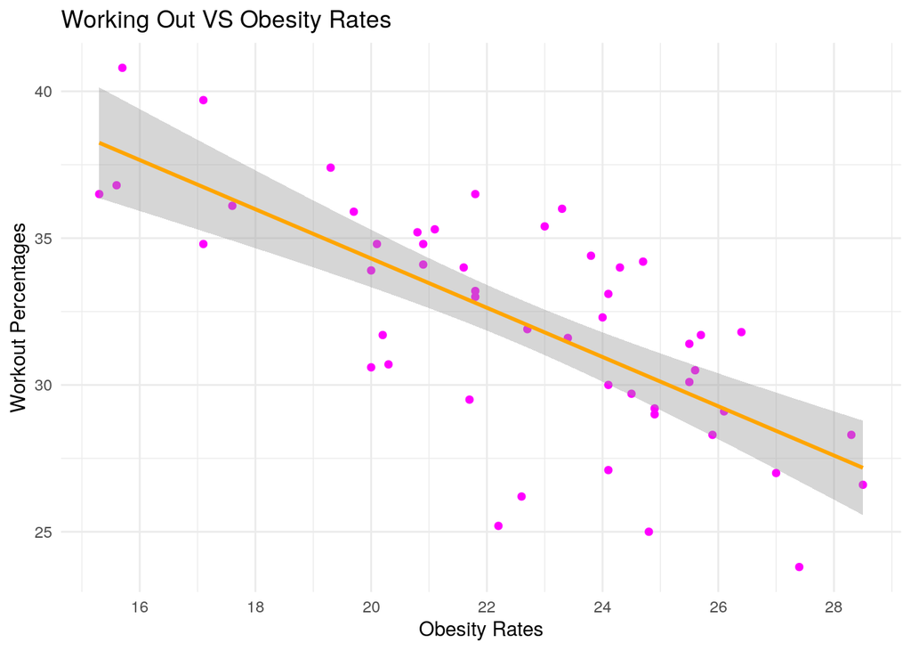

```r
alljoined %>% ggplot(aes(x = Obese, y = Workout)) + ggtitle("Working Out VS Obesity Rates") +
    geom_point(color = "magenta") + geom_smooth(method = "lm",
    color = "orange") + labs(x = "Obesity Rates", y = "Workout Percentages") +
    theme_minimal() + scale_x_continuous(n.breaks = 10)
```

This ggplot demonstrates the relationship between obesity rates across the 50 states and the workout percentages. There seems to be a correlation between the two, as highlighted by the points, as well as the linear regression running through the plot. Unsurprisingly, as obesity rates increase, the workout percentage in each state is decreasing. Similarly, the larger the percentage of people in each state that workout, the lower the obesity rate. There are some states however to be anomalies, with lower percentages of people that workout with higher obesity rates - I think that this could be due to environmental reasons.

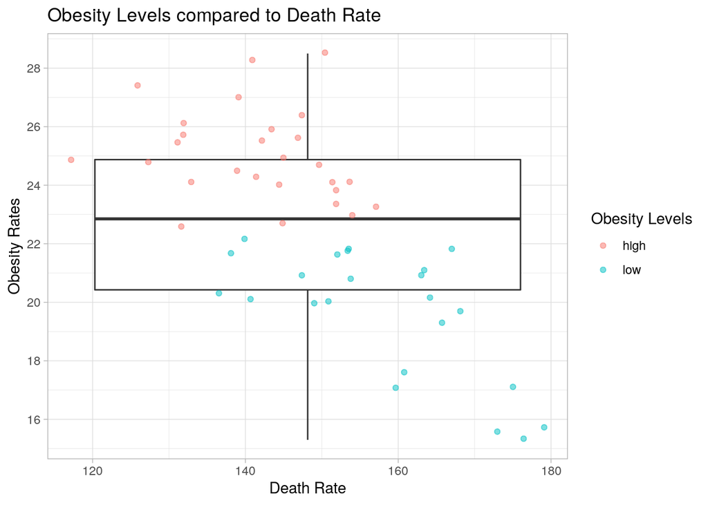

```r
alljoined %>% ggplot(aes(x = deathrate, y = Obese)) + ggtitle("Obesity Levels compared to Death Rate") +
    geom_boxplot() + geom_jitter(alpha = 0.5, aes(color = obese_hilo)) +
    labs(x = "Death Rate", y = "Obesity Rates", color = "Obesity Levels") +
    theme_light() + scale_y_continuous(n.breaks = 10)
```

This boxplot demonstrates the relationship between obesity rates and the death rate in the 50 states. I added an overlay that shows the obesity levels (the categorical variables of high obesity level or low obesity level) that demonstrate that again. Surprisingly, this boxplot shows that where there is a higher obesity rate, there is a lower death rate, and where there is a higher obesity rate, there is a lower death rate. This is extremely surprising, as I would have thought that it would have been the other way. The graph also demonstrates the mean of the death rate across all 50 states, as well as the median and quartiles of the obesity rates.

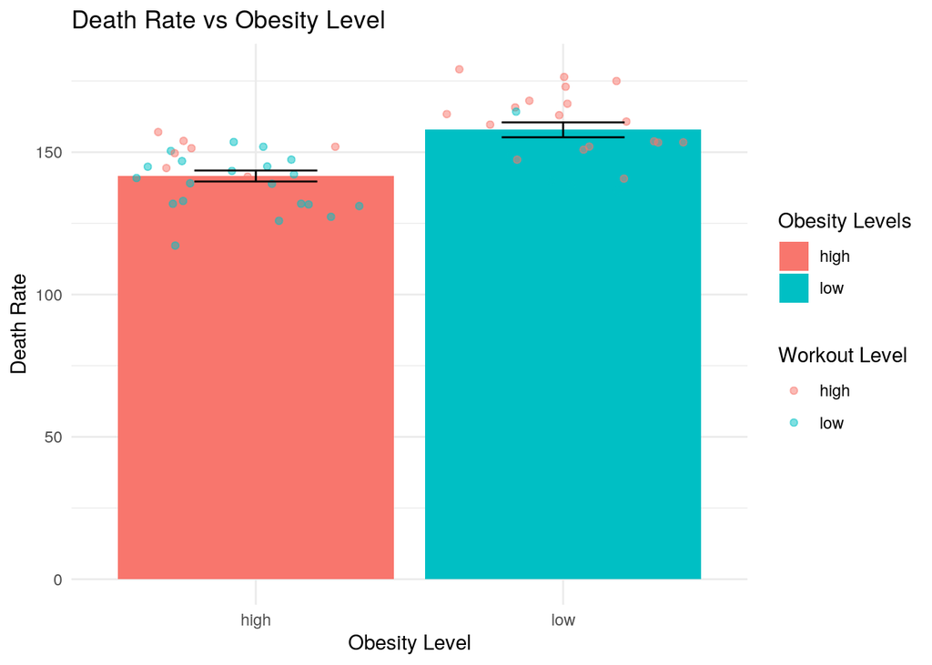

```r
alljoined %>% ggplot(aes(obese_hilo, deathrate)) + geom_bar(aes(fill = obese_hilo),
    stat = "summary", fun = mean) + labs(x = "Obesity Level",
    y = "Death Rate", color = "Workout Level", fill = "Obesity Levels") +
    ggtitle("Death Rate vs Obesity Level") + geom_jitter(alpha = 0.5,
    aes(color = workout_hilo)) + geom_errorbar(stat = "summary",
    fun.data = mean_se, width = 0.4) + theme_minimal()
```

This bar graph shows the difference between death rates regarding the obesity levels (high/low) across the United States. I then added a geom jitter over with the workout levels, which shows the relationship between the workout levels (high/low) with the obesity and death rates. This plot demonstrates that there is a significantly higher death rate (surprisingly) in states with a lower obesity level. In addition, the plot demonstrates that more frequently, a lower workout level (lower percentage of people who workout in each state) is associated with a higher obesity level, and a higher workout level (higher percentage of people who workout in each state) is associated more frequently with a lower obesity level.

#### Concluding Remarks

Cancer is something that I am extremely passionate about, and one day hope to live to see it abolished. For the time being, I am doing what I can to educate myself and others about this field and how important knowledge is about the disease. This data showed me a lot of information that I was expecting, but also information that I was not expecting, building my knowledge on cancer frequencies across the 50 states as a whole.